# Qualitative Acticity Recognition of Weight Lifting

Manni Truong

30 January 2016

## Introduction

As part of Coursera’s Practical Machine Learning course it is required to put together an assigment that incorporates the concepts learned. In particular we are given a dataset from the paper [Qualitative Activity Recognition of Weight Lifting Exercises](http://groupware.les.inf.puc-rio.br/har) (Velloso et al). The paper deals with activity recognition via a sensor approach as well as a model-based one. Rather than studying how often people exercise the paper investigates how to qualitatively measure how well people do it. This is done by specifying a correct way of doing an exercise as well as specifying wrong ways of doing it. This assigment will take the data collected from sensors on the belt, forearm, arm and dumbbell of participants to predict the manner in which they did the exercise.

## Data

### Background

The data is obtained from the study. It contains measurements on six participants who perform one set of 10 repitions of [Unilateral Dumbbell Biceps Curls](https://www.youtube.com/watch?v=YxtwA7XRK_g) in five different ways:

- class A: exactly to specification
- class B: throwing the elbows to the front
- class C: lifting dumbbell only halfway
- class D: lowering dumbbell only halfway
- class E: throwing the hips to the front

The first class (A) corrospends to doing the exercise correctly whereas the other four classes (B to E) are variations of how not to exercise.

### Loading

```r
# load libraries
library(caret)
library(parallel)
library(doParallel)

# load data
pml.training <- read.csv("pml-training.csv")
pml.testing <- read.csv("pml-testing.csv")

dim(pml.training)
```

```
## [1] 19622   160
```

The original training data set has 19622 rows and 160 columns. In the following section we will trim the number of columns down to 53.

### Cleaning

Having explored the data with the help of the paper we first remove the first 7 columns. The first column `X` is just an index.

```r
colnames(pml.training)[1:7]
```

```
## [1] "X"                    "user_name"            "raw_timestamp_part_1"
## [4] "raw_timestamp_part_2" "cvtd_timestamp"       "new_window"
## [7] "num_window"
```

The `user_name` column identifies the participant. The timestamp columns refer to the time the exercise was being done. Removing those will avoid collinarity issues with the sensor data since inherently they are correlated with the x, y and z sensor data. The window variables have been created because the paper cited earlier uses a sliding window approach for feature extraction. They are an extension of the time variables so we also remove them.

The other group of columns that we want to remove are identified as statistics variables such as the average, standard deviation, variance, minimum, maximum etc. Looking the at dataset closely those variables are only populated when the `new_window` column (which we removed) equals to yes. This is due to the sliding window approach mentioned earlier. The statistical measures are calculated over one group, i.e. the `num_window`. We remove them since we only want the actual measurements from the sensors.

```r
# remove first seven columns
to_be_removed <- c(colnames(pml.training)[1:7])
pml.training.clean <- pml.training[, !names(pml.training) %in% to_be_removed]
pml.testing.clean <- pml.testing[, !names(pml.testing) %in% to_be_removed]

# remove statistical measures
stats_cols <- colnames(pml.training)[grepl("avg|stddev|var|min|max|kurtosis|amplitude|skewness*", colnames(pml.training))]
pml.training.clean <- pml.training.clean[, !names(pml.training.clean) %in% stats_cols]
pml.testing.clean <- pml.testing.clean[, !names(pml.testing.clean) %in% stats_cols]

dim(pml.training.clean)
```

```
## [1] 19622    53
```

After the cleaning we are left with a dataset of 52 features and 1 outcome variable.

## Building models

Before we build our model, the original training dataset we loaded is split again into a training (70%) and test (30%) dataset.

```r
# set seed
set.seed(1986)

# split data into training and test
inTrain <- createDataPartition(y = pml.training.clean$classe, p = .7, list = FALSE)

pml.training.clean.training <- pml.training.clean[inTrain,]
pml.training.clean.testing <- pml.training.clean[-inTrain,]
```

### Feature correlation

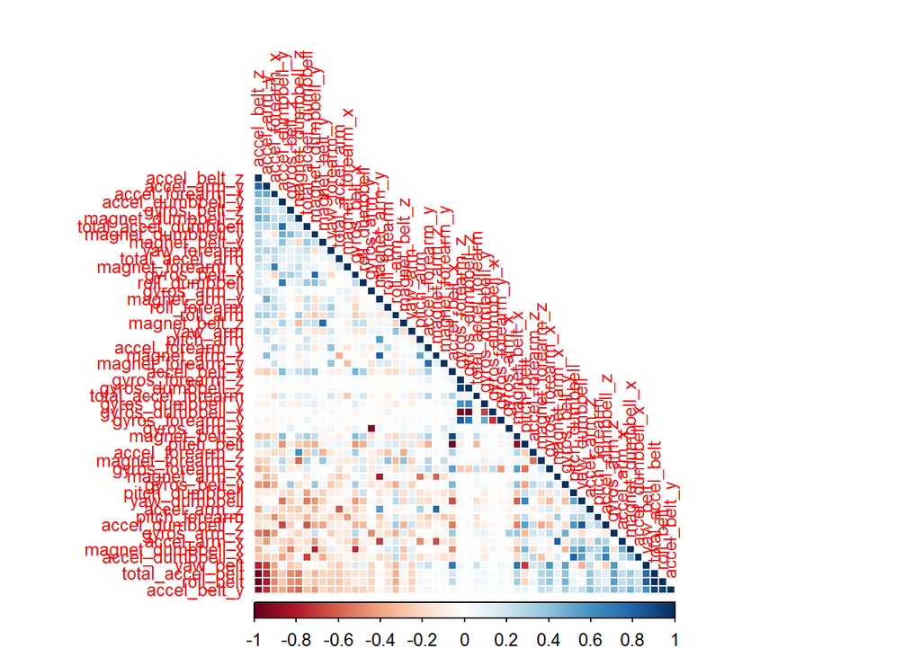

```r
cor.mat <- cor(pml.training.clean[, -53])
corrplot::corrplot(cor.mat, order = "FPC", method = "color", tl.cex = .8, type = "lower")
```

The graph shows the lower bit of the correlation matrix revealing correlations between the predictors. We are interested in the hihgly negatively (dark red) correlated features as well the highly positively (dark blue) correlated ones. The top diagonal dark blue squares can be ignored since they represent correlations with themselves, e.g. `accel_belt_z` on `accel_belt_z`. Based on the plot we decide not to bother with PCA processing to avoid complicating our model.

### Random forests

Following Leonard Greski excellent [writeup](https://github.com/lgreski/datasciencectacontent/blob/master/markdown/pml-randomForestPerformance.md) on parallel processing we follow this approach to train a model. We use the trainControl function to specify a 10 fold cross validation and allow for parallel processing.

```r
# for parallel processing
cluster <- makeCluster(detectCores() - 1) # convention to leave 1 core for OS
registerDoParallel(cluster)

fitControl <- trainControl(method = "cv",number = 10, allowParallel = TRUE)
modelFit.pml <- train(classe~., data = pml.training.clean.training, method = "rf", trControl = fitControl)

# shutting down cluster
stopCluster(cluster)
```

```r
modelFit.pml$finalModel
```

```
##
## Call:
##  randomForest(x = x, y = y, mtry = param$mtry)
##                Type of random forest: classification
##                      Number of trees: 500
## No. of variables tried at each split: 27
##
##         OOB estimate of  error rate: 0.61%
## Confusion matrix:
##      A    B    C    D    E  class.error
## A 3903    3    0    0    0 0.0007680492
## B   18 2631    7    1    1 0.0101580135
## C    0   13 2375    8    0 0.0087646077
## D    0    1   22 2228    1 0.0106571936
## E    0    1    2    6 2516 0.0035643564
```

## Prediction of new samples

```r
predictions <- predict(modelFit.pml, pml.training.clean.testing)
confusionMatrix(predictions, pml.training.clean.testing$classe)
```

```
## Confusion Matrix and Statistics
##
##           Reference
## Prediction    A    B    C    D    E
##          A 1670    5    0    0    0
##          B    3 1132    2    1    1
##          C    0    2 1022   11    1
##          D    0    0    2  950    1
##          E    1    0    0    2 1079
##
## Overall Statistics
##
##                Accuracy : 0.9946
##                  95% CI : (0.9923, 0.9963)
##     No Information Rate : 0.2845
##     P-Value [Acc > NIR] : < 2.2e-16
##
##                   Kappa : 0.9931
##  Mcnemar's Test P-Value : NA
##
## Statistics by Class:
##
##                      Class: A Class: B Class: C Class: D Class: E
## Sensitivity            0.9976   0.9939   0.9961   0.9855   0.9972
## Specificity            0.9988   0.9985   0.9971   0.9994   0.9994
## Pos Pred Value         0.9970   0.9939   0.9865   0.9969   0.9972
## Neg Pred Value         0.9990   0.9985   0.9992   0.9972   0.9994
## Prevalence             0.2845   0.1935   0.1743   0.1638   0.1839
## Detection Rate         0.2838   0.1924   0.1737   0.1614   0.1833
## Detection Prevalence   0.2846   0.1935   0.1760   0.1619   0.1839
## Balanced Accuracy      0.9982   0.9962   0.9966   0.9924   0.9983
```

We apply our model to the test set with the 20 test cases to answer the quiz question which is part of this assignment. We exclude column 53 `problem_id` which refers to the respective quizz question. Our model predictions get a 20/20 score.

```r
predictions.testing <- predict(modelFit.pml, pml.testing.clean[, -53])
predictions.testing
```

```
##  [1] B A B A A E D B A A B C B A E E A B B B
## Levels: A B C D E
```